# Part II - Loan Data from Prosper

## by Oliwia Koteluk

## Investigation Overview

In this investigation, I wanted to look at the features which might be usefull in the predicting the amount of received loans. There a lot of them which mmight be taken into account such as: monthly income, date, occupation, term, house ownership and many more.

## Dataset Overview

To be able to perform the exploration, I used the dataset which consist of more than 110 thousands of loans made by Prosper across the years 2005 and 2014.

## Loan amount distribution

In the very beggining, let's take a closer look at the main variable of interest in this exploration

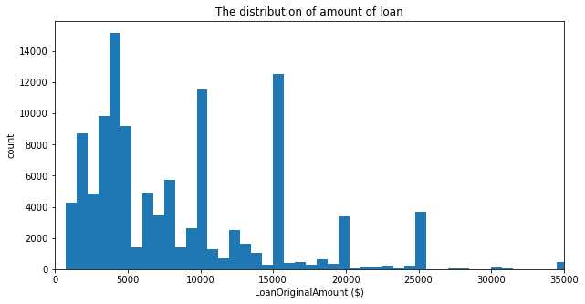

For the amount of loan in this dataset, we can observe several peaks across the distribution.

## Loan amount vs date

The dataset contains data from several different years. Over the years, the economic situation has changed, which could have had an impact on the number of loans granted.

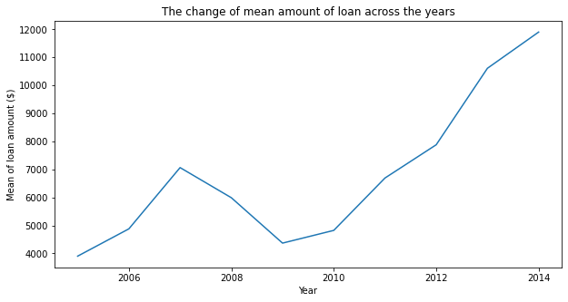

The average loans amount has been changing over the year. Since 2009 (till 2014), this number has continued to increase over time.

## Loan amount vs house ownership

In the dataset, there is also the information about the fact if borrower possess the house or not. It seems natural to say that if the borrower possess the property, he/she has a chance to receive the bigger amount of loan. Let's fins out what the relationship in this case looks like.

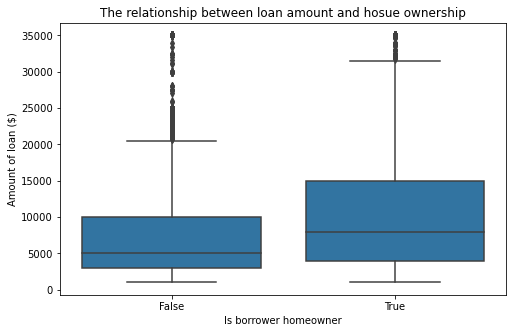

As expected, borrowers that own a house received the bigger amount of loan.

## Loan amount vs income range

Now, let's find out if people who earns more in fact received bigger amount of loans.

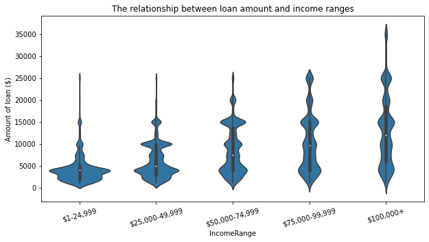

## More complex relationship - loan amount by year and house ownership

It is unlikely that the amount of granted loan will depend on only one feature, so let's look at combining more features when predicting.

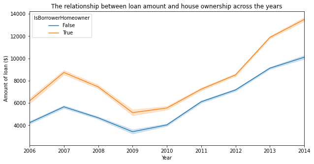

Borrowers who own the house received bigger amount of loans no matter of the year they pulled the loan than those who haven;t hadd the property. However in some years (like 2014) this change was bigger.

## More complex relationship - loan amount by year and income range

Now, let's find out what is the relationship between loan amount and income range across time. Have the more earning borrowers always taken bigger loans?

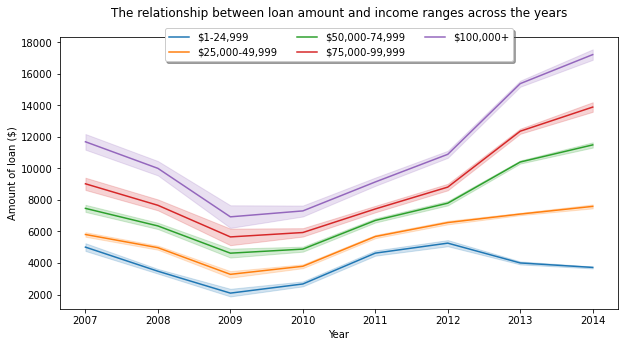

As you might expect across all analyzed period, the bigger the income the bigger the amount of loan. This situation haven't changed thoghtout the years. What's interesting is that only in the group with the lowest income, the amount of loan decreases since 2012.

## Cumulative effect of variables

Analyzed categorical features might also have the impact on each other, not only on the amount of loan. They might strengthened each other in terms of predicting the amount of loan.

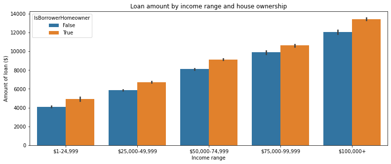

Income range and house ownership have the addictive (strengthening) effect on each other. In this case it means that when the borrower own a house, he/she can count on a larger loan while still in the same income range.

## Conclusion

The amount of loan is the features that is influenced by many different variables. Some of them are year the credit was pulled, income range and the house ownership. Among these the borrower who earns a lot of many, additionally owns the house and pulled the loan in 2014 can count on the biggest amount of loan.